# 几何光学 Project： Understand Spherical Aberration

Write codes for generating spot diagrams for lenses.

Only Snell’s Law is simply used. Basic system requirements are:

$$ \begin{align} Aperture\space Diameter &= 30 mm\\ EFL &=100 mm\\ n &= 1.51680\\ Lens\space thickness &= 7.2 mm\\ \end{align} $$

Plot spot diagram Find the minimized GEO (Geometrical radius) on Gaussian image plane.

## 第1问

A biconvex lens, curvatures $C_1 = -C_2$. Find the Geometrical radius on Gaussian image plane.

#### 1. 实验结果

#### 2. 实验原理与过程

#### 3. 实验可视化

#### 4. 实验总结

### 1. 实验结果

当$c_1 = -c_2$时，实验结果为： $$ GEO = 0.562419043908779mm $$

Ray Tracing的结果（实验未作要求）Spot Diagram的结果分别如下：

```python
from IPython.display import Image
rt1 = Image(filename='./ray_tracing_1.png')
sd1 = Image(filename='./spot_diagram.png')
```

Ray Tracing的结果（实验未作要求）:

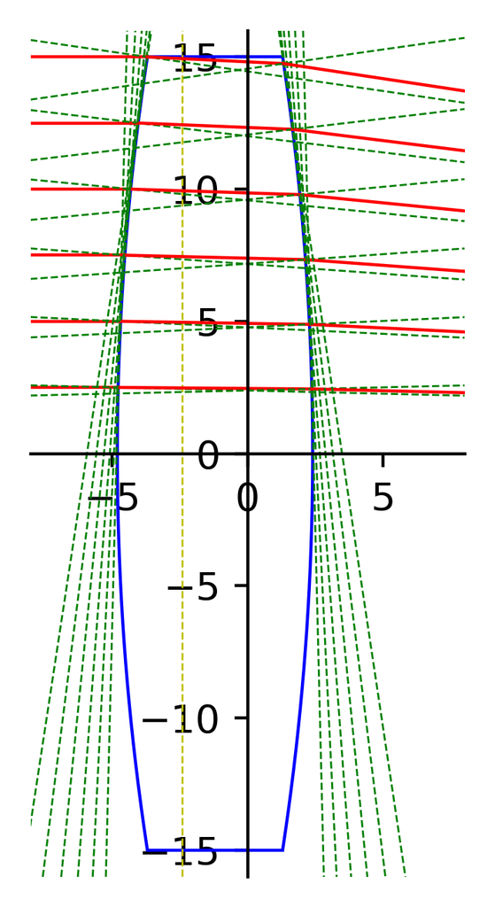

```python
rt1
```

Spot Diagram的结果:

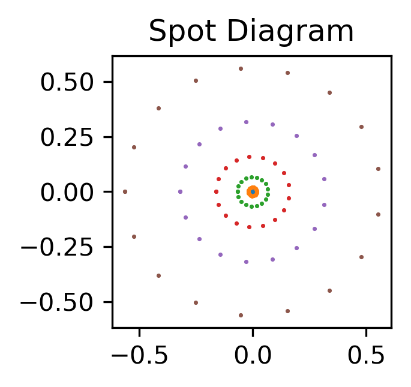

```python
sd1
```

### 2. 实验原理与过程

本实验使用的语言为Python。和商业化，集成度高的Matlab不同，Python是开源且极为灵活的语言。直接使用Python完成本实验会有困难，故我们`import`一些（第三方）包来帮助完成实验。

```python
import numpy as np
import sympy as sym
import matplotlib.pyplot as plt
%matplotlib inline
```

对于Project的第一小问，最值得一提的包就是[sympy](https://www.sympy.org/en/index.html)了。这个包很强大，可以利用它解代数方程。不仅仅可以得到方程的解，还可以得到方程的代数表达式。

```python
# 让显示出来的代数表达式更加易于阅读
sym.init_printing()
```

```python
# 建立一个var类，用于变量的值和代数表达式。
class var():
    def __init__(self, str):
        self.s = sym.Symbol(str)
        self.v = None
```

首先，初始化一些已知条件和必要的参数。

```python
x = var('x')
K = var('K')
n = var('n')
d = var('d')
apt_d = var('AD')
mu = n
c1, c2 = var('c_1'), var('c_2')
R1, R2 = var('R_1'), var('R_2')
K1, K2 = var('K_1'), var('K_2')
delta, delta_P = var('delta'), var('\delta^{\prime}')

K.v = 1/100.0
n.v = 1.5168
d.v = 7.2
apt_d.v = 30
```

以下是一些确定透镜相关参数的公式： $$ \begin{align} K &= K_1 + K_2 - \frac{d}{\mu}K_1K_2 \\ K_1 &= c_1(\mu - 1) \\ K_2 &= c_2(1 - mu) \end{align} $$

通过以上公式，并利用$EFL = 100$以及$c_1 = -c_2$联立求解出$c_1$和$c_2$的值。

```python
def eq1(get_val=False): return c1.s + c2.s if get_val else c1.s + c2.s

def eq2(get_val=False): return K.v - (n.v - 1)*(c1.s - c2.s) - (d.v/mu.v)*c1.s*c2.s*(mu.v - 1)**2 if get_val \
else K.s - (n.s - 1)*(c1.s - c2.s) - (d.s/mu.s)*c1.s*c2.s*(mu.s - 1)**2

def eq2(get_val=False): return K.v - (n.v - 1)*(c1.s - c2.s) - (d.v/mu.v)*c1.s*c2.s*(mu.v - 1)**2 if get_val \
else K.s - (n.s - 1)*(c1.s - c2.s) - (d.s/mu.s)*c1.s*c2.s*(mu.s - 1)**2
```

```python
sym.solve([eq1(), eq2()], [c1.s, c2.s])
```

$$\left [ \left ( \frac{n}{d \left(n - 1\right)} - \frac{\sqrt{- n \left(K d - n\right)} \left(n - 1\right)}{d \left(n^{2} - 2 n + 1\right)}, \quad - \frac{n}{d \left(n - 1\right)} + \frac{\sqrt{- n \left(K d - n\right)} \left(n - 1\right)}{d \left(n^{2} - 2 n + 1\right)}\right ), \quad \left ( \frac{n}{d \left(n - 1\right)} + \frac{\sqrt{- n \left(K d - n\right)} \left(n - 1\right)}{d \left(n^{2} - 2 n + 1\right)}, \quad - \frac{n}{d \left(n - 1\right)} - \frac{\sqrt{- n \left(K d - n\right)} \left(n - 1\right)}{d \left(n^{2} - 2 n + 1\right)}\right )\right ]$$

```python
c1.v, c2.v = (sym.solve([eq1(True), eq2(True)], [c1.s, c2.s]))[0]
print(c1.v, c2.v)
```

```
0.00979254439042120 -0.00979254439042120
```

我们得到了$c_1 = -c_2 = 0.00979254439042120mm$

下面求解主面的位置，并将像方主面与光轴的交点设定为原点。 利用公式:

$$\normalsize \delta^{\prime} = \frac{-n^{\prime} d K_1}{\mu K}$$ 以及 $$\normalsize \delta = \frac{ n d K_2}{\mu K}$$ 求解可得：

```python
K1.v = c1.v*(n.v - 1)
K2.v = c2.v*(1-n.v)

delta_P.v = -(d.v*K1.v)/(mu.v*K.v)
delta.v   = (d.v*K2.v)/(mu.v*K.v)
```

以像方主面与光轴的交点$P^{\prime}$为坐标原点，即: $O = P^{\prime}$。并建立直角坐标系。下面求圆心$C_1$和$C_2$的位置。设透镜与光轴的两个交点从左到右依次为$Q，Q^{\prime}$，那么有: $QQ^{\prime} = d$。

圆心$C_1$的坐标为: $$C_1(P^{\prime}C_1, 0)$$ 其中，

$$ \begin{align} P^{\prime}C_1 &= P^{\prime}Q^{\prime} + Q^{\prime}Q + QC_1\\ &= -\delta^{\prime} - d + R_1\\ &= R_1 -\delta^{\prime} - d \end{align} $$

圆心$C_2$的坐标为: $$C_2(P^{\prime}C_2, 0)$$ 其中，

$$ \begin{align} P^{\prime}C_2 &= P^{\prime}Q^{\prime} + Q^{\prime}C_2^{\prime}\\ &= -\delta^{\prime}+ R_2\\ &= R_2 -\delta^{\prime} \end{align} $$

在这里，$R_2$小于零。

```python
C1, C2 = var('C_1'), var('C_2')
R1.v = 1/c1.v
R2.v = 1/c2.v
C1.v = R1.v - delta_P.v - d.v
C2.v = R2.v - delta_P.v

print(C1.v, C2.v)
```

```
97.3207779667135 -99.7162334025018
```

以上就是定义两个透镜的两个圆的圆心坐标。

解决完了又经相关参数的问题，下面的代码是用来确定透镜的具体形状的，这些参数和Ray Tracing无关，是用来画透镜的（实验未作要求）。

首先确定两个圆张开的角度：

```python
theta = var('theta')
def eq1(get_sym=True): return R1.s*sym.sin(theta.s) - apt_d.s/2 if get_sym \
    else R1.v*sym.sin(theta.s) - apt_d.v/2

def eq2(get_sym=True): return R1.s*sym.sin(theta.s) + apt_d.s/2 if get_sym \
    else R1.v*sym.sin(theta.s) + apt_d.v/2
```

```python
sym.solve(eq1(), theta.s)
```

$$\left [ - \operatorname{asin}{\left (\frac{AD}{2 R_{1}} \right )} + \pi, \quad \operatorname{asin}{\left (\frac{AD}{2 R_{1}} \right )}\right ]$$

```python
sym.solve(eq2(), theta.s)
```

$$\left [ \operatorname{asin}{\left (\frac{AD}{2 R_{1}} \right )} + \pi, \quad - \operatorname{asin}{\left (\frac{AD}{2 R_{1}} \right )}\right ]$$

```python
sym.solve(eq1(False), theta.s)
```

$$\left [ 0.147421574370244, \quad 2.99417107921955\right ]$$

```python
sym.solve(eq2(False), theta.s)
```

$$\left [ -0.147421574370244, \quad 3.28901422796004\right ]$$

以上的两个数组就是两个圆$C_1$和$C_2$张开的角度。

```python
_, theta_lower = sym.solve(eq1(False), theta.s)
_, theta_upper = sym.solve(eq2(False), theta.s)
theta_lower = float(theta_lower)
theta_upper = float(theta_upper)
```

下面是Ray Tracing的过程，首先要求出，chief ray与透镜的第一个交点，以及在交点处，对园$C_1$切线的斜率：

```python
x0 = var('x_0')
y0 = var('y_0')
expr = sym.sqrt(R1.s**2 - (x0.s - C1.s)**2)
sym.diff(expr, x0.s)
```

$$\frac{C_{1} - x_{0}}{\sqrt{R_{1}^{2} - \left(- C_{1} + x_{0}\right)^{2}}}$$

以上就是切线斜率$slope_1$的代数表达式。

由几何关系知，入射角$i_{1}$可以通过如下公式计算： $$ sini_{1} = \frac{1}{\sqrt{1 + slope_{1}^{2}}} $$ 而$slope_{1}$就是图中切线的斜率，刚刚已经求得。

```python
y0.v = float(15)
x0.v = C1.v - np.sqrt(float(R1.v**2 - y0.v**2))
slope_1 = (C1.v - x0.v)/np.sqrt(float(R1.v**2 - (-C1.v + x0.v)**2))
print(-1/slope_1)
```

```
-0.148498917906343
```

上面的代码块求出了切线斜率的负倒数，也就是第一次折射入射光法线的斜率。

由折射定律可求得第一次折射的折射角$i^{'}_{1}$: $$ sini_{1} = nsini^{'}_{1} $$ 并依据几何关系，得到出射光线的斜率，用$slope_2$表示。

```python
i1   = np.arcsin(float(y0.v/R1.v))
i1_P = np.arcsin(float(y0.v/R1.v)/n.v)
```

```python
theta_1 = i1_P - i1
```

```python
slope_2 = np.tan(theta_1)
```

$$ Chief Ray与透镜的第一个面的交点横坐标: x_0 $$

$$ Chief Ray与透镜的第一个面的交点纵坐标: y_0 $$

下面求解发生第二次折射的情形：

设光线和第二个折射面的交点坐标为:$(x_1, y_1)$

```python
x1 = var('x_1')
y1 = var('y_1')
```

```python
def eq(): return sym.sqrt(-(x.s - C2.v)**2 + R2.v**2) - \
(slope_2*(x.s - x0.v) + y0.v)
```

```python
x1.v = sym.solve(eq(), x.s)[1]
y1.v = slope_2*(x1.v - x0.v) + y0.v
```

```python
sym.init_printing()
expr = sym.sqrt(R2.s**2 - (x1.s - C2.s)**2)
sym.diff(expr, x1.s)
```

$$\frac{C_{2} - x_{1}}{\sqrt{R_{2}^{2} - \left(- C_{2} + x_{1}\right)^{2}}}$$

```python
sym.init_printing(pretty_print=False)
expr = sym.sqrt(R2.s**2 - (x1.s - C2.s)**2)
sym.diff(expr, x1.s)
```

```
(C_2 - x_1)/sqrt(R_2**2 - (-C_2 + x_1)**2)
```

```python
slope_3 = (C2.v - x1.v)/np.sqrt(float(R2.v**2 - (-C2.v + x1.v)**2))
print(-1/slope_3)
```

```
0.145935703489876
```

与之前的情况类似，上面几个代码块求解的是切线和法线的斜率。法线的斜率为：$0.145935703489876$

下面利用折射定律和一些基本的几何关系求解经过两次折射后，出射光的斜率。加上前面所求的交点坐标$(x_1, y_1)$，可求得出射光线的方程。

```python
# 第二个折射面的入射角
theta_2 = -theta_1 + np.arctan(float(-1/slope_3))
```

```python
# 第二个折射面的折射角
theta_2P = np.arcsin(n.v*np.sin(theta_2))
```

```python
np.arctan(float(-1/slope_3)) - theta_2P
```

```
-0.15392870848008364
```

```python
# 经由第二个折射面折射所得的光线的斜率
slope = np.tan(np.arctan(float(-1/slope_3)) - theta_2P)
```

现在我们知道了斜率，我们可以吧$x = EFL = 100$带入方程，得到$GEO$的值。

```python
print(abs((slope*(1/K.v - x1.v) + y1.v)))
```

```
0.562419043908779
```

于是，对于第一小问，我们有： $$ GEO = 0.562419043908779mm $$

### 3. 实验结果可视化

#### 可视化分两部分，一是Ray Tracing，而是Spot Diagram

首先是Ray Tracing，这部分没做要求，但是我觉得Zemax能画，我也能画。实际上，这部分代码比较复杂，实现起来比较困难。

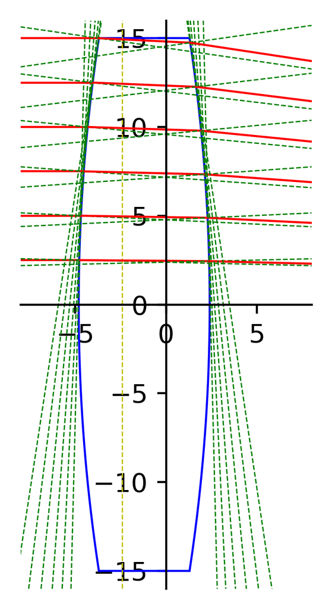

```
CPU时间(cpu time): 180.913723 s
```

```python
import time

cpu_start = time.clock()

# 设置画布
plt.figure(figsize=(2, 4), dpi=400)
plt.xlim((-8, 8))
plt.ylim((-16, 16))

# 设置坐标轴属性
ax = plt.gca()
ax.spines['right'].set_color('none')
ax.spines['top'].set_color('none')
ax.spines['bottom'].set_position(('data',0))
ax.spines['left'  ].set_position(('data',0))


# 以下是透镜相关的可视化部分

# 描述两圆的角度范围，透镜的左右面范围
ang = np.arange(theta_lower, theta_upper, 0.0005)
# 描述透镜上下底面范围
ll0 = np.arange(C1.v+ R1.v*np.cos(theta_lower), C2.v+ R2.v*np.cos(theta_lower), 0.01)
# 描述各个面切线和法线的范围，即全明面
xx0 = np.arange(-30, 30, 0.01)



# 两圆相交所得透镜的折射面方程
plt.plot(C1.v + R1.v*np.cos(ang), R1.v*np.sin(ang), 'b', linewidth=0.8)
plt.plot(C2.v + R2.v*np.cos(ang), R2.v*np.sin(ang), 'b', linewidth=0.8)

# 透镜的上面和下面，由直线方程描述。
plt.plot(ll0, apt_d.v/2 + 0*ll0, 'b', linewidth=0.8)
plt.plot(ll0, -apt_d.v/2 + 0*ll0, 'b', linewidth=0.8)

# 物方主面的方程
plt.plot(-delta_P.v - d.v + delta.v + xx0*0, xx0, 'y--', linewidth=0.5)



def ray_tracing(h=30, plt_ray_tracing=True, plt_spot_diagram=True):
    y0.v = float(h/2)
    x0.v = C1.v - np.sqrt(float(R1.v**2 - y0.v**2))
    slope_1 = (C1.v - x0.v)/np.sqrt(float(R1.v**2 - (-C1.v + x0.v)**2))

    i1   = np.arcsin(float(y0.v/R1.v))
    i1_P = np.arcsin(float(y0.v/R1.v)/n.v)

    theta_1 = i1_P - i1

    slope_2 = np.tan(theta_1)

    x1 = var('x_1')
    y1 = var('y_1')

    def eq(): return sym.sqrt(-(x.s - C2.v)**2 + R2.v**2) - \
    (slope_2*(x.s - x0.v) + y0.v)

    x1.v = sym.solve(eq(), x.s)[1]
    y1.v = slope_2*(x1.v - x0.v) + y0.v

    sym.init_printing()
    expr = sym.sqrt(R2.s**2 - (x1.s - C2.s)**2)
    sym.diff(expr, x1.s)

    sym.init_printing(pretty_print=False)
    expr = sym.sqrt(R2.s**2 - (x1.s - C2.s)**2)
    sym.diff(expr, x1.s)

    slope_3 = (C2.v - x1.v)/np.sqrt(float(R2.v**2 - (-C2.v + x1.v)**2))

    # 第二个折射面的入射角
    theta_2 = -theta_1 + np.arctan(float(-1/slope_3))

    # 第二个折射面的折射角
    theta_2P = np.arcsin(n.v*np.sin(theta_2))

    np.arctan(float(-1/slope_3)) - theta_2P

    # 经由第二个折射面折射所得的光线的斜率
    slope = np.tan(np.arctan(float(-1/slope_3)) - theta_2P)

    r = slope*(1/K.v - x1.v) + y1.v

    # 以下是光线Ray Tracing的可视化部分

    # 描述入射光x取值范围
    xx1 = np.arange(-30, x0.v, 0.01)
    # 描述第一次折射后，折射光x的取值范围
    xx1P = np.arange(x0.v, x1.v, 0.001)
    # 描述第二次折射后，折射光x的取值范围
    xx2 = np.arange(x1.v, 120, 0.001)

    # 入射光方程
    plt.plot(xx1,  y0.v + 0*xx1, 'r', linewidth=0.8)

    # 第一个折射面，入射点处，切线和法线的方程。
    plt.plot(xx0, slope_1*(xx0 - x0.v) + y0.v, 'g--', linewidth=0.5)
    plt.plot(xx0, (-1/slope_1)*(xx0 - x0.v) + y0.v, 'g--', linewidth=0.5)

    # 发生第一次折射后，折射光的方程。
    plt.plot(xx1P, slope_2*(xx1P - x0.v) + y0.v, 'r', linewidth=0.8)

    # 第二个折射面，入射点处，切线和法线的方程。
    plt.plot(xx0, slope_3*(xx0 - x1.v) + y1.v, 'g--', linewidth=0.5)
    plt.plot(xx0, (-1/slope_3)*(xx0 - x1.v) + y1.v, 'g--', linewidth=0.5)

    # 发生第二次折射后，折射光的方程。
    plt.plot(xx2, slope*(xx2 - x1.v) + y1.v, 'r', linewidth=0.8)

    return r

r_list = []
for h in [5, 10, 15, 20, 25, 30]:
    r_list.append(ray_tracing(h))

plt.show()

cpu_end = time.clock()
print('CPU时间(cpu time):', cpu_end - cpu_start, 's')
```

**以上就是Ray Tracing的可视化结果。其中：**

**蓝色线为透镜**

**黄色线为主面**

**绿色虚线为切线和法线**

**红色线为光线**

除了做出Ray Tracing的可视化结果以外，我还特意记录了CPU的运行时间。CPU时间为181s。

**记录CPU时间的原因是，复杂度和运行时间也是衡量算法的重要指标。后面将使用改进的算法解决更复杂的第三问可视化问题，并将两者的CPU时间进行比较。**

下面是Spot Diagram的代码的可视化结果。单位为mm.

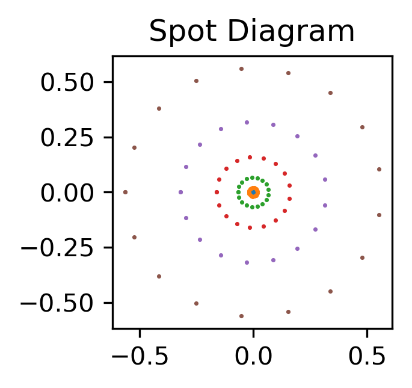

```python
ang = np.linspace(0, 2*np.pi, 18)

plt.figure(figsize=(2, 2), dpi=300)

area = 0.5

for r in r_list:
    plt.scatter(r*np.cos(ang), r*np.sin(ang), s=area, marker='o')
    plt.title('Spot Diagram')
plt.show()
```

### 4. 实验总结

**这是光学Project的第一个小实验。代码不是很成熟，运行效率较低。整个实验报告带有“探索”的性质，很少使用函数，列表和字典等。力求复原最开始的求解心路历程。所以看起来会比较杂乱啰嗦。后面的实验将会改进代码性能，缩短报告篇幅。**